# HW4

Sean Morris

2024-03-08

# Logs

- Fix Lasso, Ridge, PLS, PCR
- Figure out how to insert images
- Double check everything for quality
- Bootstraps and selection error charts are fine

# Question 2

[interactive chart not shown]

## Part g

*Create a plot that displays, for each integer value of n from 1 to 100,000, the probability that the jth observation is in the bootstrap sample. Comment on what you observe.*

```r
# Initialize function for calculating values
func_g = function(n) {
  return (1 - (1 - (1/n))^n)
}

# Sequence from 1 to 100,000
n_values = 1:100000

# Applying func_g over the sequence
g_values = sapply(n_values, func_g)

# Combining n_values and g_values into a dataframe
df_g = data.frame(n = n_values, p = g_values)

# Displaying the first few rows of the dataframe
head(df_g)
```

```
##   n         p
## 1 1 1.0000000
## 2 2 0.7500000
## 3 3 0.7037037
## 4 4 0.6835938
## 5 5 0.6723200
## 6 6 0.6651020
```

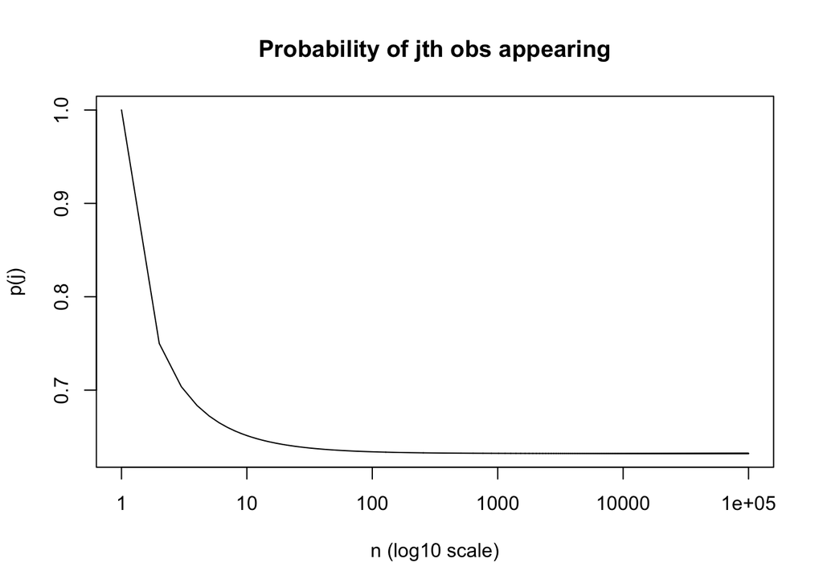

```r
# Plotting
plot(df_g$n, df_g$p, log = "x", xaxt = "n", type = "l",
     xlab = "n (log10 scale)", ylab = "p(j)",
     main = "Probability of jth obs appearing")
axis(1, at = 10^seq(0, 5, by = 1), labels = 10^seq(0, 5, by = 1))
```

- As the number of observations approaches infinity, the probability that the j’th value appears in the bootstrap data set appraoches a number around 0.6321

## Part h

```r
set.seed(777)

store = rep(NA, 10000)
for(i in 1:10000) {
  store[i] = sum(sample(1:100, rep=TRUE) == 4) > 0
}

mean(store)
```

```
## [1] 0.6236
```

- For the simulated sample of 10000 observations, the probability that j=4 appears in the bootstrap sample is approximately equal to our theorized value of 0.6321.

# Question 8

## Part a

```r
rm(list = ls())

# Generating simulated data
set.seed(1)
x = rnorm(100)
y = x - 2 * x^2 + rnorm(100)
```

- n = 100
- p = 1

$$X \sim \mathcal{N}(0,1) ; \quad \varepsilon \sim \mathcal{N}(0,1) ;
\quad n = 100$$

$$Y = X - 2X^2 + \varepsilon$$

## Part b

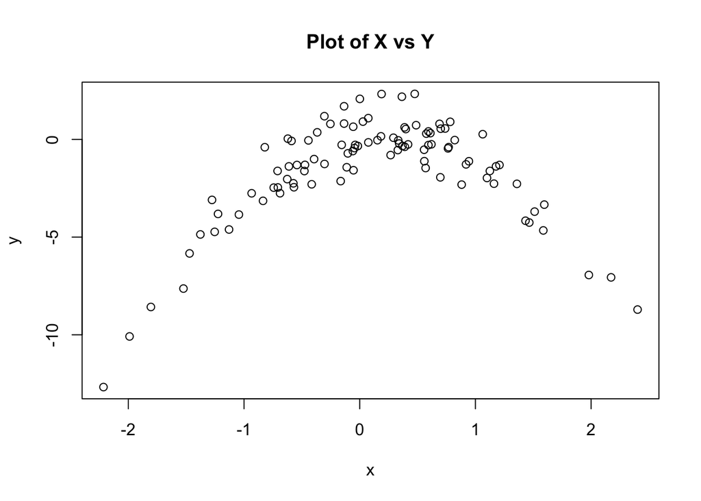

```r
plot(x,y,
     main = "Plot of X vs Y")
```

- Scatter plot of X vs Y shows a non-linear relationship between the two variables

## Part c

```r
set.seed(1789)

# Setting initial data frame and error df
df_c = data.frame(x, y)
n = length(df_c$x)
errors_c = data.frame(model_i=rep(NA, n),
                      model_ii=rep(NA, n),
                      model_iii=rep(NA, n),
                      model_iv=rep(NA, n))


# Running LOOCV
for (i in 1:n) {
  # Define the training and test sets
  train = df_c[-i, ]
  test = df_c[i, ]

  # Fit the four models
  model_i = lm(y ~ x, data=train)
  model_ii = lm(y ~ x + I(x^2), data=train)
  model_iii = lm(y ~ x + I(x^2) + I(x^3), data=train)
  model_iv = lm(y ~ x + I(x^2) + I(x^3) + I(x^4), data=train)

  # Make predictions and calculate errors
  pred_i = predict(model_i, newdata=test)
  pred_ii = predict(model_ii, newdata=test)
  pred_iii = predict(model_iii, newdata=test)
  pred_iv = predict(model_iv, newdata=test)

  errors_c$model_i[i] = test$y - pred_i
  errors_c$model_ii[i] = test$y - pred_ii
  errors_c$model_iii[i] = test$y - pred_iii
  errors_c$model_iv[i] = test$y - pred_iv
}

# View the first few rows of the errors dataframe
head(errors_c)
```

```
##       model_i    model_ii   model_iii   model_iv
## 1  0.02800453 -0.63069876 -0.66185177 -0.6268523
## 2  1.67341498 -0.01394833 -0.01095102 -0.1087138
## 3 -0.95931181 -0.88908574 -0.92497289 -0.8259236
## 4 -2.92603344  0.39868225  0.40169676  0.6316514
## 5  0.86418447 -0.71465323 -0.70642882 -0.7935211
## 6  1.83221641  1.84306805  1.83472527  1.9461865
```

## Part d

```r
set.seed(1231)

errors_c2 = data.frame(model_i=rep(NA, n),
                      model_ii=rep(NA, n),
                      model_iii=rep(NA, n),
                      model_iv=rep(NA, n))

# Running LOOCV
for (i in 1:n) {
  # Define the training and test sets
  train = df_c[-i, ]
  test = df_c[i, ]

  # Fit the four models
  model_i2 = lm(y ~ x, data=train)
  model_ii2 = lm(y ~ x + I(x^2), data=train)
  model_iii2 = lm(y ~ x + I(x^2) + I(x^3), data=train)
  model_iv2 = lm(y ~ x + I(x^2) + I(x^3) + I(x^4), data=train)

  # Make predictions and calculate errors
  pred_i2 = predict(model_i2, newdata=test)
  pred_ii2 = predict(model_ii2, newdata=test)
  pred_iii2 = predict(model_iii2, newdata=test)
  pred_iv2 = predict(model_iv2, newdata=test)

  errors_c2$model_i[i] = test$y - pred_i2
  errors_c2$model_ii[i] = test$y - pred_ii2
  errors_c2$model_iii[i] = test$y - pred_iii2
  errors_c2$model_iv[i] = test$y - pred_iv2
}

print(sum(errors_c == errors_c2))
```

```
## [1] 400
```

- Respective LOOCV errors are likely the same because the seed used to generate the initial data set remained unchanged. Therefore, the two methods are applied to the same data set, with no other dependencies.

## Part e

```r
cat(" Model i mean", mean(errors_c$model_i), "\n\n",
    "Model ii mean", mean(errors_c$model_ii), "\n\n",
    "Model iii mean", mean(errors_c$model_iii), "\n\n",
    "Model iv mean", mean(errors_c$model_iv))
```

```
##  Model i mean -0.03646299
##
##  Model ii mean 0.00264074
##
##  Model iii mean 0.007875966
##
##  Model iv mean -0.0007800036
```

- Model 4 exhibits the smallest LOOCV error, a result that is intuitively aligned with its quartic functional form, which provides a nuanced and flexible fit for the data’s underlying patterns. Similarly, the quadratic model’s performance, evidenced by the second-lowest error metric, coherently mirrors the observed inverse parabolic trend within the dataset. This concordance suggests that the models with even polynomial degrees are better at capturing curvature inherent in the data.

## Part f

```r
summary(model_i)
```

```
##
## Call:
## lm(formula = y ~ x, data = train)
##
## Residuals:
##     Min      1Q  Median      3Q     Max
## -9.4983 -0.7029  0.7013  1.5781  3.8245
##
## Coefficients:
##             Estimate Std. Error t value Pr(>|t|)
## (Intercept)  -1.6326     0.2647  -6.167  1.6e-08 ***
## x             0.6973     0.2930   2.380   0.0193 *
## ---
## Signif. codes:  0 '***' 0.001 '**' 0.01 '*' 0.05 '.' 0.1 ' ' 1
##
## Residual standard error: 2.613 on 97 degrees of freedom
## Multiple R-squared:  0.05518,    Adjusted R-squared:  0.04544
## F-statistic: 5.665 on 1 and 97 DF,  p-value: 0.01926
```

```r
summary(model_ii)
```

```
##
## Call:
## lm(formula = y ~ x + I(x^2), data = train)
##
## Residuals:
##     Min      1Q  Median      3Q     Max
## -1.9711 -0.6375 -0.1308  0.5997  2.2660
##
## Coefficients:
##             Estimate Std. Error t value Pr(>|t|)
## (Intercept)  0.06240    0.11892   0.525    0.601
## x            1.01442    0.10864   9.338 3.94e-15 ***
## I(x^2)      -2.12052    0.08521 -24.886  < 2e-16 ***
## ---
## Signif. codes:  0 '***' 0.001 '**' 0.01 '*' 0.05 '.' 0.1 ' ' 1
##
## Residual standard error: 0.9621 on 96 degrees of freedom
## Multiple R-squared:  0.8732, Adjusted R-squared:  0.8706
## F-statistic: 330.5 on 2 and 96 DF,  p-value: < 2.2e-16
```

```r
summary(model_iii)
```

```
##
## Call:
## lm(formula = y ~ x + I(x^2) + I(x^3), data = train)
##
## Residuals:
##     Min      1Q  Median      3Q     Max
## -1.9845 -0.6446 -0.1070  0.5654  2.2820
##
## Coefficients:
##             Estimate Std. Error t value Pr(>|t|)
## (Intercept)  0.06819    0.12094   0.564    0.574
## x            0.96672    0.18905   5.113 1.64e-06 ***
## I(x^2)      -2.12614    0.08753 -24.291  < 2e-16 ***
## I(x^3)       0.02002    0.06478   0.309    0.758
## ---
## Signif. codes:  0 '***' 0.001 '**' 0.01 '*' 0.05 '.' 0.1 ' ' 1
##
## Residual standard error: 0.9667 on 95 degrees of freedom
## Multiple R-squared:  0.8733, Adjusted R-squared:  0.8693
## F-statistic: 218.3 on 3 and 95 DF,  p-value: < 2.2e-16
```

```r
summary(model_iv)
```

```
##
## Call:
## lm(formula = y ~ x + I(x^2) + I(x^3) + I(x^4), data = train)
##
## Residuals:
##     Min      1Q  Median      3Q     Max
## -2.0635 -0.6427 -0.1457  0.6107  2.2241
##
## Coefficients:
##              Estimate Std. Error t value Pr(>|t|)
## (Intercept)  0.163859   0.140915   1.163    0.248
## x            1.022214   0.193056   5.295 7.79e-07 ***
## I(x^2)      -2.413207   0.235949 -10.228  < 2e-16 ***
## I(x^3)      -0.006774   0.067707  -0.100    0.921
## I(x^4)       0.070005   0.053465   1.309    0.194
## ---
## Signif. codes:  0 '***' 0.001 '**' 0.01 '*' 0.05 '.' 0.1 ' ' 1
##
## Residual standard error: 0.9631 on 94 degrees of freedom
## Multiple R-squared:  0.8756, Adjusted R-squared:  0.8703
## F-statistic: 165.4 on 4 and 94 DF,  p-value: < 2.2e-16
```

# Question 9

## Part a & b

```r
rm(list=ls())
#install.packages("ISLR2")
library(ISLR2)
data("Boston")
attach(Boston)


# Estimate for popultation mean and standard error
mu_medv = mean(Boston$medv)
se_medv = sqrt(var(Boston$medv)) / sqrt(length(Boston$medv))

cat(" Mean:", mu_medv,"\n\n",
    "StdErr:", se_medv)
```

```
##  Mean: 22.53281
##
##  StdErr: 0.4088611
```

- The population mean of medv is approximately 22.53, plus or minus 0.4088 units

## Part c

```r
set.seed(1989)

store = rep(NA, 10000)
for(i in 1:10000) {
  store[i] = mean(sample(Boston$medv, length(Boston$medv), rep=TRUE))
}

mu_boot = mean(store)
se_boot = sd(store)

cat(" Est. Mean: ", mu_medv, "\n",
    "Bootstrap: ", mu_boot, "\n\n",
    "Est. SE:   ", se_medv, "\n",
    "Bootstrap: ", se_boot)
```

```
##  Est. Mean:  22.53281
##  Bootstrap:  22.53362
##
##  Est. SE:    0.4088611
##  Bootstrap:  0.408724
```

## Part d

```r
# 95 CI for the mean of medv:
UCI = mu_boot + 2*se_boot
LCI = mu_boot - 2*se_boot

cat(" 95% Confidence Interval for Mean medv:\n\n",
    "[",LCI,",",UCI,"]")
```

```
##  95% Confidence Interval for Mean medv:
##
##  [ 21.71617 , 23.35107 ]
```

```r
t.test(Boston$medv)
```

```
##
##  One Sample t-test
##
## data:  Boston$medv
## t = 55.111, df = 505, p-value < 2.2e-16
## alternative hypothesis: true mean is not equal to 0
## 95 percent confidence interval:
##  21.72953 23.33608
## sample estimates:
## mean of x
##  22.53281
```

- The confidence interval found via the boot strap method is within one decimal from the CI found using the t-test method

## Part e

```r
set.seed(1992)

# Median
median_medv = median(Boston$medv)

# Boot strap method to find standard error
store_median = rep(NA, 10000)
for(i in 1:10000) {
  store_median[i] = median(sample(Boston$medv, length(Boston$medv), rep=TRUE))
}

median_boot = mean(store_median)
se_med_boot = sd(store_median)

cat(" Est. Median:      ", median_medv, "\n",
    "Bootstrap Median: ", median_boot, "\n\n",
    "Est. Median SE:   ", se_med_boot)
```

```
##  Est. Median:       21.2
##  Bootstrap Median:  21.18386
##
##  Est. Median SE:    0.3756291
```

- Both the median and its estimated standard error are smaller than the mean and its respective standard error - likely because the median and its bootstrap standard error tend to be smaller than those of the mean due to the median’s lower sensitivity to outliers and skewed distributions.

## Part g

```r
set.seed(1234)

# Estimating Quantile
q_ten = quantile(Boston$medv, .10)

# Boot strap method
store_quantiles = rep(NA, 10000)
for(i in 1:10000) {
  store_quantiles[i] = quantile(sample(Boston$medv, length(Boston$medv), rep=TRUE), probs = .10)
}

q_ten_boot = mean(store_quantiles)
se_q_ten_boot = sd(store_quantiles)

cat(" Est. 10th Prcntl:      ", q_ten, "\n",
    "Bootstrap 10th Prcntl: ", q_ten_boot, "\n\n",
    "SE Bootstrap:          ", se_q_ten_boot)
```

```
##  Est. 10th Prcntl:       12.75
##  Bootstrap 10th Prcntl:  12.7654
##
##  SE Bootstrap:           0.4983203
```

# Question 1

*We perform best subset, forward stepwise, and backward stepwise selection on a single data set. For each approach, we obtain p + 1 models, containing 0,1,2,…, p predictors. Explain your answers:*

## Part a

- I would expect best subset selection to have the lowest training RSS, as the algorithm in this case parses through every possible combination of features, and therefore can extract the lowest possible RSS from the data it is modelling.

## Part b

- It is not possible to determine which type of model selection would yield the lowest test RSS, as we would need to see how well each model selection performs on unseen data.

## Part c

*i*

- True, as the sequence of feature selections for any k-feature forward stepwise selection will always be the same

*ii*

- True, similar to forward stepwise selection, the sequence of features selected for any k-feature backward stepwise selection will be the same.

*iii*

- False, as the collection of selected features in a forward stepwise selection may be different than the collection found in backward stepwise selection.

*iv*

- False. Similarly, because forward stepwise selection and backward stepwise selection operate on different principles (adding for forward and removing for backward), the k-variable model from forward stepwise selection is not necessarily a subset of the k+1-variable model from backward stepwise selection.

*v*

- False, as the best subset selection evaluates all possible combinations of predictors separately for each model size, so the k-variable model’s predictors are not guaranteed to be a subset of the k+1-variable.

# Question 3

*Suppose we estimate the regression coefficients in a linear regression model by minimizing*

$$\min \left( \sum_{i=1}^{n} \left( y_i - \beta_0 - \sum_{j=1}^{p} \beta_j
x_{ij} \right)^2 \right) \quad \text{subject to} \quad \sum_{j=1}^{p}
\left| \beta_j \right| \leq s$$

## Part a - Training RSS

- *i*, Increasing the optimization constraint initially causes the training RSS to rise, but as the constraint loosens, allowing for more complex models, the training RSS decreases before increasing again due to over fitting.

## Part b - Test RSS

- *ii*, Elevating s from 0 improves test data fit, reducing test RSS until a point where further increases lead to over fitting on the training data, which then escalates test RSS.

## Part c - Variance

- *iv*, as the optimization constraint on coefficients is relaxed, the model’s variability initially increases, reflecting a tendency to over fit the data.

## Part d - Squared bias

- *iii*, placing greater emphasis on the coefficients can make the model conform too closely to the training data, leading to an increase in bias as the model begins to over fit.

## Part e - irriducible error

- *v*, as the irreducible error is not affected by the model’s complexity. Rather, it is determined by the noise within the data itself, which is not changed by the model selection process.

# Question 8

## Part a

```r
rm(list=ls())
set.seed(1112)

x = rnorm(100)
```

## Part b

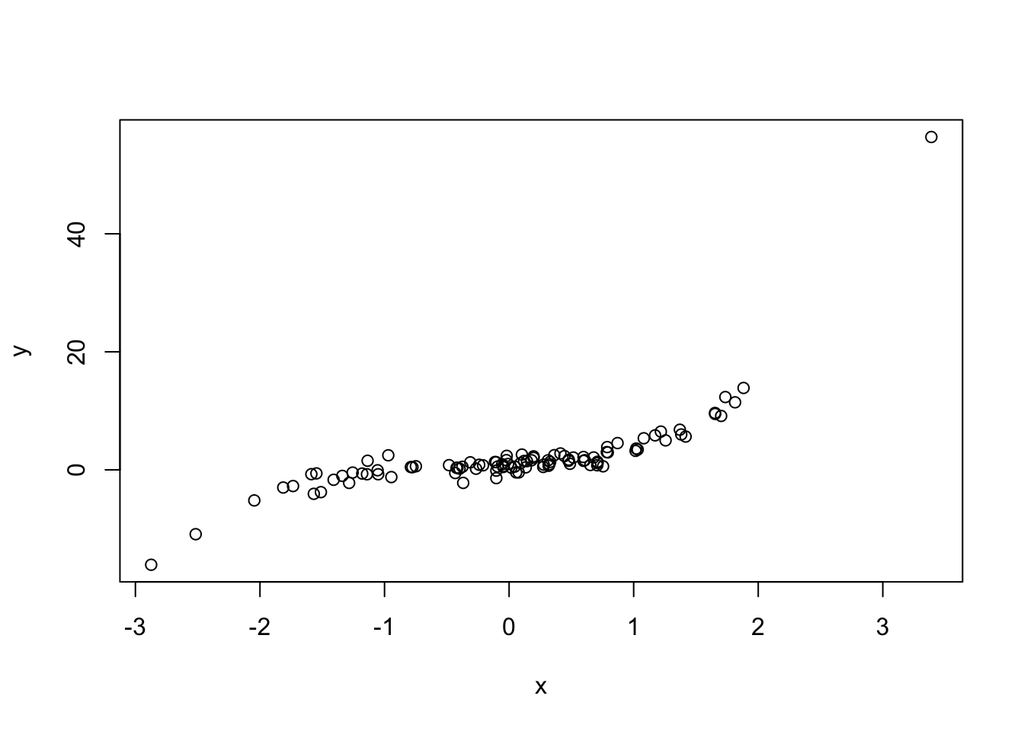

```r
y = 1 + x + I(x^2) + I(x^3) + rnorm(100)

plot(x,y)
```

## Part c & d

```r
# install.packages("leaps")
library(leaps)

x_df = data.frame(y=y,
                  x1=x,
                  x2=I(x^2),
                  x3=I(x^3),
                  x4=I(x^4),
                  x5=I(x^5),
                  x6=I(x^6),
                  x7=I(x^7),
                  x8=I(x^8),
                  x9=I(x^9),
                  x10=I(x^10))

regfit.full = regsubsets(y ~ ., data = x_df, nvmax = 10)
reg.summary = summary(regfit.full)

reg.summary
```

```
## Subset selection object
## Call: regsubsets.formula(y ~ ., data = x_df, nvmax = 10)
## 10 Variables  (and intercept)
##     Forced in Forced out
## x1      FALSE      FALSE
## x2      FALSE      FALSE
## x3      FALSE      FALSE
## x4      FALSE      FALSE
## x5      FALSE      FALSE
## x6      FALSE      FALSE
## x7      FALSE      FALSE
## x8      FALSE      FALSE
## x9      FALSE      FALSE
## x10     FALSE      FALSE
## 1 subsets of each size up to 10
## Selection Algorithm: exhaustive
##           x1  x2  x3  x4  x5  x6  x7  x8  x9  x10
## 1  ( 1 )  " " " " "*" " " " " " " " " " " " " " "
## 2  ( 1 )  " " "*" "*" " " " " " " " " " " " " " "
## 3  ( 1 )  "*" "*" "*" " " " " " " " " " " " " " "
## 4  ( 1 )  "*" "*" "*" "*" " " " " " " " " " " " "
## 5  ( 1 )  "*" "*" "*" "*" " " " " " " " " "*" " "
## 6  ( 1 )  "*" "*" "*" "*" "*" " " " " " " "*" " "
## 7  ( 1 )  "*" "*" "*" " " " " " " "*" "*" "*" "*"
## 8  ( 1 )  "*" "*" "*" "*" " " "*" "*" "*" "*" " "
## 9  ( 1 )  "*" "*" "*" "*" " " "*" "*" "*" "*" "*"
## 10  ( 1 ) "*" "*" "*" "*" "*" "*" "*" "*" "*" "*"
```

```r
regfit.forward = regsubsets(y ~ ., data = x_df, nvmax = 10, method = "forward")
fwd.summary = summary(regfit.forward)
regfit.backward = regsubsets(y ~ ., data = x_df, nvmax = 10, method = "backward")
bkwd.summary = summary(regfit.backward)
```

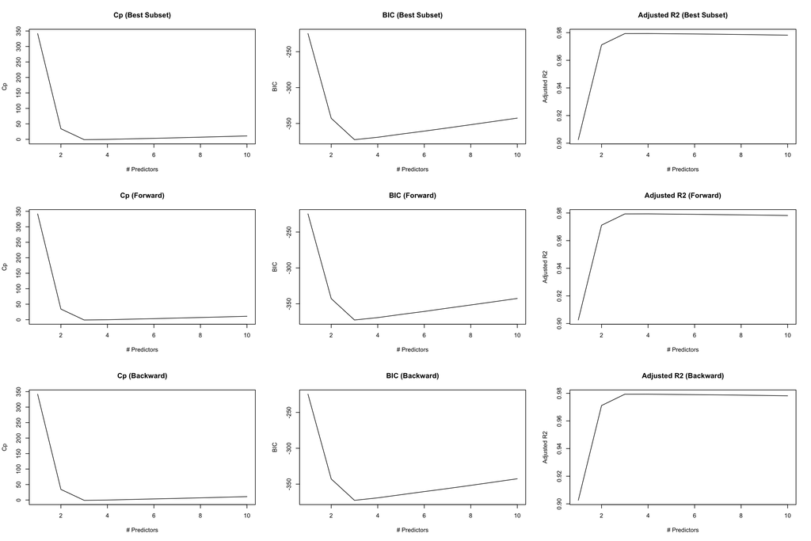

```r
par(mfrow = c(3,3))

## Best Subset

plot(reg.summary$cp,
     type = "line",
     xlab = "# Predictors",
     ylab = "Cp",
     main = "Cp (Best Subset)")

plot(reg.summary$bic,
     type = "line",
     xlab = "# Predictors",
     ylab = "BIC",
     main = "BIC (Best Subset)")

plot(reg.summary$adjr2,
     type = "line",
     xlab = "# Predictors",
     ylab = "Adjusted R2",
     main = "Adjusted R2 (Best Subset)")

## Forward Step

plot(fwd.summary$cp,
     type = "line",
     xlab = "# Predictors",
     ylab = "Cp",
     main = "Cp (Forward)")

plot(fwd.summary$bic,
     type = "line",
     xlab = "# Predictors",
     ylab = "BIC",
     main = "BIC (Forward)")

plot(fwd.summary$adjr2,
     type = "line",
     xlab = "# Predictors",
     ylab = "Adjusted R2",
     main = "Adjusted R2 (Forward)")

## Backward Step

plot(bkwd.summary$cp,
     type = "line",
     xlab = "# Predictors",
     ylab = "Cp",
     main = "Cp (Backward)")

plot(bkwd.summary$bic,
     type = "line",
     xlab = "# Predictors",
     ylab = "BIC",
     main = "BIC (Backward)")

plot(bkwd.summary$adjr2,
     type = "line",
     xlab = "# Predictors",
     ylab = "Adjusted R2",
     main = "Adjusted R2 (Backward)")
```

- At a glance, it appears as though all methods yield identical results to each other. This likely occurred as a result of the limited amount of sample observations.

## Part e

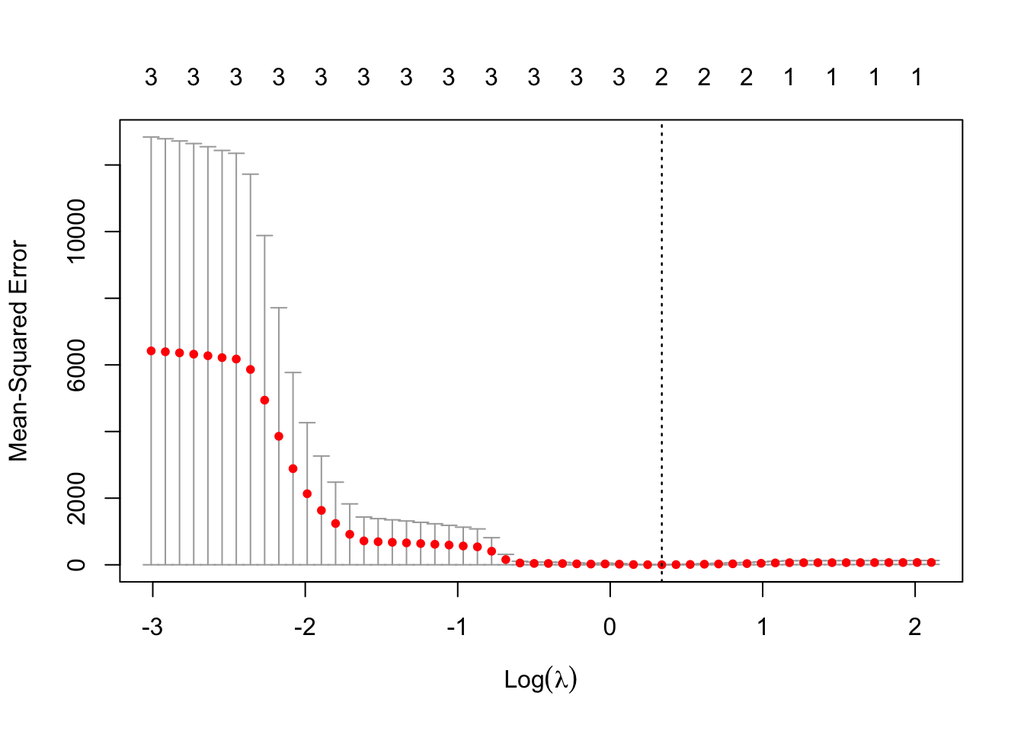

```r
#install.packages("glmnet")
library(glmnet)
x = as.matrix(x)
x_df = x_df[,-1]
x_df = as.matrix(x_df)
y = as.matrix(y)

set.seed(1789)
train = sample(1:nrow(x), nrow(x) / 2)
y.test = y[-train,]

# Running initial lasso
reg.lasso = glmnet(x_df[train,], y[train], alpha = 1)

# Running K-Fold CV for optimal lambda
set.seed(1789)
cv.out = cv.glmnet(x_df[train,], y[train,1], alpha = 1)
plot(cv.out)
```

```r
# Best lambda value
bestlam = cv.out$lambda.min

# Running prediction on Test Data
lasso.pred = predict(reg.lasso, s = bestlam,
                     newx = x_df[-train,], type = "coefficients")

lasso.pred
```

```
## 11 x 1 sparse Matrix of class "dgCMatrix"
##                   s1
## (Intercept) 1.275721
## x1          .
## x2          0.476154
## x3          1.060769
## x4          .
## x5          .
## x6          .
## x7          .
## x8          .
## x9          .
## x10         .
```

- All coefficients aside from x2 and x3 constrained to zero. Feature x3 has the highest magnitude effect on response variable y.

## Part f

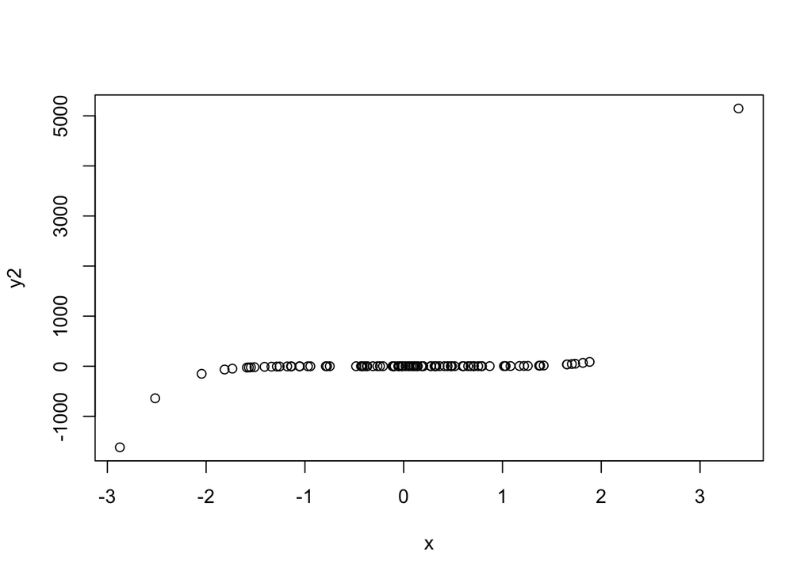

```r
set.seed(1112)

y2 = 1 + I(x^7) + rnorm(100)
plot(x, y2)
```

```r
## Best Subset
x_df = as.data.frame(x_df)

subset.partf = regsubsets(y2 ~ ., data = x_df, nvmax = 10)
subset.summary = summary(subset.partf)

subset.summary
```

```
## Subset selection object
## Call: regsubsets.formula(y2 ~ ., data = x_df, nvmax = 10)
## 10 Variables  (and intercept)
##     Forced in Forced out
## x1      FALSE      FALSE
## x2      FALSE      FALSE
## x3      FALSE      FALSE
## x4      FALSE      FALSE
## x5      FALSE      FALSE
## x6      FALSE      FALSE
## x7      FALSE      FALSE
## x8      FALSE      FALSE
## x9      FALSE      FALSE
## x10     FALSE      FALSE
## 1 subsets of each size up to 10
## Selection Algorithm: exhaustive
##           x1  x2  x3  x4  x5  x6  x7  x8  x9  x10
## 1  ( 1 )  " " " " " " " " " " " " "*" " " " " " "
## 2  ( 1 )  "*" " " " " " " " " " " "*" " " " " " "
## 3  ( 1 )  "*" " " " " " " " " " " "*" " " "*" " "
## 4  ( 1 )  "*" "*" " " " " " " "*" "*" " " " " " "
## 5  ( 1 )  "*" "*" " " " " " " " " "*" " " "*" "*"
## 6  ( 1 )  "*" "*" " " "*" " " "*" "*" " " "*" " "
## 7  ( 1 )  "*" "*" " " "*" "*" "*" "*" " " "*" " "
## 8  ( 1 )  "*" "*" " " "*" "*" "*" "*" "*" " " "*"
## 9  ( 1 )  "*" "*" "*" "*" "*" "*" "*" "*" " " "*"
## 10  ( 1 ) "*" "*" "*" "*" "*" "*" "*" "*" "*" "*"
```

```r
## Lasso ##

y2.test = y2[-train,]

y2 = as.matrix(y2)
x_df = as.matrix(x_df)

# Running initial lasso
reg.lasso2 = glmnet(x_df[train,], y2[train], alpha = 1)

# Running K-Fold CV for optimal lambda
set.seed(1789)
cv.out2 = cv.glmnet(x_df[train,], y2[train], alpha = 1)
# plot(cv.out2)

# Best lambda value
bestlam2 = cv.out2$lambda.min

# Running prediction on Test Data
lasso.pred2 = predict(reg.lasso2, s = bestlam2,
                     newx = x_df[-train,], type = "coefficients")

lasso.pred2
```

```
## 11 x 1 sparse Matrix of class "dgCMatrix"
##                       s1
## (Intercept) 1.9749416036
## x1          .
## x2          .
## x3          .
## x4          .
## x5          0.6892848431
## x6          0.6595902547
## x7          0.7110669376
## x8          .
## x9          0.0005424238
## x10         .
```

- Results obtained for new model drop all coefficients besides those for x5-x7 and x9. Coefficient value for x7 has highest magnitude effect on response variable likely due to similarity with underlying structure of output variable.